# Debunking the Misconceptions in Relation to COVID-19 Incidents

### Introduction

A huge pandemic swept through the world during 2020 called COVID-19. It has been the largest pandemic of the decade. It had an alarmingly fast spread rate, and has caused hundreds of millions of deaths as of the end of 2022. Many are still suffering from hasting heath problems and many high risk and older groups are still wary about going out and about even now when the deaths from COVID are lowering as it still can cause severe symptoms as well cause major inconveniences in everyday life.  
I am exploring this topic as I remember that during the beginning and peak of covid many people were in the dark about how COVID spread and how it was caught. This misinformation spread rapidly over the internet and made many people scared to leave their homes at all as well as hoard goods. Having data and concrete evidence could have helped to calm people down as keep order in society in such an unstable time. Although personally I was not severely impacted by this kind of ambiguous information, I understand how easy it was to believe it and create unconscious biases towards different people as well as institutions.  
I will be analyzing different aspects of covid to shed some light on the misconceptions that some people may have about the cause of COVID-19. This tutorial will help teach how to collect data, manage the data, perform exploratory data analyses, do hypothesis testing, and pull insights from the results.

I searched for statistics about covid's consequences and impact which is where I found The COVID Tracking project by The Atlantic Monthly Group. They collected data about COVID-19 in the US and compiling the data into easy to read datasets.  
First I used https://covidtracking.com/data to get basic covid information like cases, deaths, and hospitalizations. Then I found https://covidtracking.com/race which had some useful data about the impact of race on the number of cases.

### 1. Data collection/curation

First I will discuss some of the libraries that will be used in this tutorial to help make it easier to analyze the data. Resources to better understand each are linked after each description.  
Pandas: Used for data manipulation and analyses.  
https://pandas.pydata.org/  
Datetime: Python supplied classes to help manipulate dates and times.  
https://docs.python.org/3/library/datetime.html  
Matplotlib: Library for creating static, animated, and interactive visualizations.  
https://matplotlib.org/  
Sklearn: Scikit-learn is machine learning in python, a tool for predictive data analysis.  
https://scikit-learn.org/stable/  
Statsmodels: A python module that helps to conduct statistical tests.  
https://www.statsmodels.org/stable/index.html

```python
import pandas as pd
from datetime import datetime
import matplotlib.pyplot as plt
from sklearn.linear_model import LinearRegression
import statsmodels.api as sm
import statsmodels.formula.api as smf
```

I took the two datasets that I had found and loaded them both into python using pandas's read_csv function. Then I displayed some of the first entries in each file to check that the information received was correct.

```python
#read in the data table
covid_table = pd.read_csv("covid-all-states-history.csv")
display(covid_table.head())

race_table = pd.read_csv("CRDT Data - CRDT.csv")
display(race_table.head())
```

|  | date | state | death | deathConfirmed | deathIncrease | deathProbable | hospitalized | hospitalizedCumulative | hospitalizedCurrently | hospitalizedIncrease | ... | totalTestResults | totalTestResultsIncrease | totalTestsAntibody | totalTestsAntigen | totalTestsPeopleAntibody | totalTestsPeopleAntigen | totalTestsPeopleViral | totalTestsPeopleViralIncrease | totalTestsViral | totalTestsViralIncrease |
| --- | --- | --- | --- | --- | --- | --- | --- | --- | --- | --- | --- | --- | --- | --- | --- | --- | --- | --- | --- | --- | --- |
| 0 | 2021-03-07 | AK | 305.0 | NaN | 0 | NaN | 1293.0 | 1293.0 | 33.0 | 0 | ... | 1731628.0 | 0 | NaN | NaN | NaN | NaN | NaN | 0 | 1731628.0 | 0 |
| 1 | 2021-03-07 | AL | 10148.0 | 7963.0 | -1 | 2185.0 | 45976.0 | 45976.0 | 494.0 | 0 | ... | 2323788.0 | 2347 | NaN | NaN | 119757.0 | NaN | 2323788.0 | 2347 | NaN | 0 |
| 2 | 2021-03-07 | AR | 5319.0 | 4308.0 | 22 | 1011.0 | 14926.0 | 14926.0 | 335.0 | 11 | ... | 2736442.0 | 3380 | NaN | NaN | NaN | 481311.0 | NaN | 0 | 2736442.0 | 3380 |
| 3 | 2021-03-07 | AS | 0.0 | NaN | 0 | NaN | NaN | NaN | NaN | 0 | ... | 2140.0 | 0 | NaN | NaN | NaN | NaN | NaN | 0 | 2140.0 | 0 |
| 4 | 2021-03-07 | AZ | 16328.0 | 14403.0 | 5 | 1925.0 | 57907.0 | 57907.0 | 963.0 | 44 | ... | 7908105.0 | 45110 | 580569.0 | NaN | 444089.0 | NaN | 3842945.0 | 14856 | 7908105.0 | 45110 |

5 rows × 41 columns

|  | Date | State | Cases_Total | Cases_White | Cases_Black | Cases_Latinx | Cases_Asian | Cases_AIAN | Cases_NHPI | Cases_Multiracial | ... | Tests_Latinx | Tests_Asian | Tests_AIAN | Tests_NHPI | Tests_Multiracial | Tests_Other | Tests_Unknown | Tests_Ethnicity_Hispanic | Tests_Ethnicity_NonHispanic | Tests_Ethnicity_Unknown |
| --- | --- | --- | --- | --- | --- | --- | --- | --- | --- | --- | --- | --- | --- | --- | --- | --- | --- | --- | --- | --- | --- |
| 0 | 20210307 | AK | 59332.0 | 18300.0 | 1499.0 | NaN | 2447.0 | 12238.0 | 1508.0 | 4453.0 | ... | NaN | NaN | NaN | NaN | NaN | NaN | NaN | NaN | NaN | NaN |
| 1 | 20210307 | AL | 499819.0 | 160347.0 | 82790.0 | NaN | 2273.0 | NaN | NaN | NaN | ... | NaN | NaN | NaN | NaN | NaN | NaN | NaN | NaN | NaN | NaN |
| 2 | 20210307 | AR | 324818.0 | 207596.0 | 50842.0 | NaN | 2913.0 | 1070.0 | 3358.0 | 1804.0 | ... | NaN | NaN | NaN | NaN | NaN | NaN | NaN | NaN | NaN | NaN |
| 3 | 20210307 | AS | NaN | NaN | NaN | NaN | NaN | NaN | NaN | NaN | ... | NaN | NaN | NaN | NaN | NaN | NaN | NaN | NaN | NaN | NaN |
| 4 | 20210307 | AZ | 826454.0 | 308453.0 | 25775.0 | 244539.0 | 11921.0 | 40707.0 | NaN | NaN | ... | NaN | NaN | NaN | NaN | NaN | NaN | NaN | NaN | NaN | NaN |

5 rows × 54 columns

These datasets are huge with a lot of data collected in different ways. For example, there were a lot of columns that talked about different types of death datapoints collected, but for personal use the numerical value for death was enough. Dropped columns contained unneeded information, redundant information, or extremely detailed information that was not really provided well.

```python
#drop the unused columns for the covid table
covid_table = covid_table.drop(columns=['deathIncrease', 'deathConfirmed', 'deathProbable', 'hospitalizedIncrease', 'hospitalizedCumulative', 'hospitalizedCurrently', 'inIcuCumulative', 'inIcuCurrently',
                                'negativeIncrease', 'negativeTestsAntibody', 'negativeTestsPeopleAntibody', 'negativeTestsViral', 'onVentilatorCumulative', 'onVentilatorCurrently',
                                'positiveIncrease', 'positiveCasesViral', 'positiveScore', 'positiveTestsAntibody', 'positiveTestsAntigen', 'positiveTestsPeopleAntibody',
                                'positiveTestsPeopleAntigen', 'positiveTestsViral', 'totalTestResultsIncrease', 'totalTestEncountersViral', 'totalTestEncountersViralIncrease',
                                'totalTestsAntibody', 'totalTestsAntigen', 'totalTestsPeopleAntibody', 'totalTestsPeopleAntigen', 'totalTestsPeopleViral',
                                'totalTestsPeopleViralIncrease', 'totalTestsViral', 'totalTestsViralIncrease'])
covid_table.head()
```

|  | date | state | death | hospitalized | negative | positive | recovered | totalTestResults |
| --- | --- | --- | --- | --- | --- | --- | --- | --- |
| 0 | 2021-03-07 | AK | 305.0 | 1293.0 | NaN | 56886.0 | NaN | 1731628.0 |
| 1 | 2021-03-07 | AL | 10148.0 | 45976.0 | 1931711.0 | 499819.0 | 295690.0 | 2323788.0 |
| 2 | 2021-03-07 | AR | 5319.0 | 14926.0 | 2480716.0 | 324818.0 | 315517.0 | 2736442.0 |
| 3 | 2021-03-07 | AS | 0.0 | NaN | 2140.0 | 0.0 | NaN | 2140.0 |
| 4 | 2021-03-07 | AZ | 16328.0 | 57907.0 | 3073010.0 | 826454.0 | NaN | 7908105.0 |

Like how I dropped columns unused above for the first table I did the same for the 2nd table. More specifically I dropped some race information that would have confused people and stuck with using easily identifiable information.

```python
#drop the unused columns for the race table
race_table = race_table.drop(columns=['Cases_Total', 'Cases_Latinx', 'Cases_Asian', 'Cases_AIAN', 'Cases_NHPI', 'Cases_Multiracial', 'Cases_Other', 'Cases_Unknown',
                               'Cases_Ethnicity_Hispanic', 'Cases_Ethnicity_NonHispanic', 'Cases_Ethnicity_Unknown', 'Deaths_Latinx', 'Deaths_Asian', 'Deaths_AIAN',
                               'Deaths_NHPI', 'Deaths_Multiracial', 'Deaths_Other', 'Deaths_Unknown', 'Deaths_Ethnicity_Hispanic', 'Deaths_Ethnicity_NonHispanic',
                               'Deaths_Ethnicity_Unknown', 'Hosp_Total', 'Hosp_Latinx', 'Hosp_Asian', 'Hosp_AIAN', 'Hosp_NHPI', 'Hosp_Multiracial', 'Hosp_Other', 'Hosp_Unknown',
                               'Hosp_Ethnicity_Hispanic', 'Hosp_Ethnicity_NonHispanic', 'Hosp_Ethnicity_Unknown', 'Tests_Total', 'Tests_Latinx', 'Tests_Asian', 'Tests_AIAN', 'Tests_NHPI',
                               'Tests_Multiracial', 'Tests_Other', 'Tests_Unknown', 'Tests_Ethnicity_Hispanic', 'Tests_Ethnicity_NonHispanic', 'Tests_Ethnicity_Unknown',
                                'Hosp_White', 'Hosp_Black', 'Tests_White', 'Tests_Black'])

race_table.head()
```

|  | Date | State | Cases_White | Cases_Black | Deaths_Total | Deaths_White | Deaths_Black |
| --- | --- | --- | --- | --- | --- | --- | --- |
| 0 | 20210307 | AK | 18300.0 | 1499.0 | 305.0 | 127.0 | 9.0 |
| 1 | 20210307 | AL | 160347.0 | 82790.0 | 10148.0 | 4730.0 | 2223.0 |
| 2 | 20210307 | AR | 207596.0 | 50842.0 | 5319.0 | 4171.0 | 784.0 |
| 3 | 20210307 | AS | NaN | NaN | NaN | NaN | NaN |
| 4 | 20210307 | AZ | 308453.0 | 25775.0 | 16328.0 | 8066.0 | 433.0 |

### 2. Data management/representation

The first things to do was to make sure all the information is understandable in the visual format that I will be using it in the future. Luckily all my data was numerical, and for areas where the data was NaN it was easy to convert into the appropriate number. All the numbers are describing people so it was all integers and so 0 was the most appropriate when there was no data collected, no people were present for the current value.

```python
#change null values to 0 on covid table
covid_table = covid_table.fillna(0)
display(covid_table.head())

race_table = race_table.fillna(0)
display(race_table.head())
```

|  | date | state | death | hospitalized | negative | positive | recovered | totalTestResults |
| --- | --- | --- | --- | --- | --- | --- | --- | --- |
| 0 | 2021-03-07 | AK | 305.0 | 1293.0 | 0.0 | 56886.0 | 0.0 | 1731628.0 |
| 1 | 2021-03-07 | AL | 10148.0 | 45976.0 | 1931711.0 | 499819.0 | 295690.0 | 2323788.0 |
| 2 | 2021-03-07 | AR | 5319.0 | 14926.0 | 2480716.0 | 324818.0 | 315517.0 | 2736442.0 |
| 3 | 2021-03-07 | AS | 0.0 | 0.0 | 2140.0 | 0.0 | 0.0 | 2140.0 |
| 4 | 2021-03-07 | AZ | 16328.0 | 57907.0 | 3073010.0 | 826454.0 | 0.0 | 7908105.0 |

|  | Date | State | Cases_White | Cases_Black | Deaths_Total | Deaths_White | Deaths_Black |
| --- | --- | --- | --- | --- | --- | --- | --- |
| 0 | 20210307 | AK | 18300.0 | 1499.0 | 305.0 | 127.0 | 9.0 |
| 1 | 20210307 | AL | 160347.0 | 82790.0 | 10148.0 | 4730.0 | 2223.0 |
| 2 | 20210307 | AR | 207596.0 | 50842.0 | 5319.0 | 4171.0 | 784.0 |
| 3 | 20210307 | AS | 0.0 | 0.0 | 0.0 | 0.0 | 0.0 |
| 4 | 20210307 | AZ | 308453.0 | 25775.0 | 16328.0 | 8066.0 | 433.0 |

The next thing to clean up the data was to focus on the date. Both tables were sorted by date and then further by state. To make the dates more readable I used python datetime to convert them to a date time which can be easily manipulated in the future and keeps the presentation consistent.  
There were thousands of rows of data sorted by the specific date which is very difficult to understand the data on a bigger and more broad scale. It is hard to understand how time passes by just looking at the date but the month would be easier for others to understand. To fix this I consolidated the data points by the month and summed the other values in the rows as they are all numeric and are values that are accumulated.

```python
#condense the dates for each day into a month
covid_table['date']= pd.to_datetime(covid_table['date'])
#only keep the information for the month and year
covid_table['date'] = covid_table['date'].dt.to_period('M')
covid_table = covid_table.groupby(['date', 'state'], as_index=False).sum()
display(covid_table.head())

#change the strings to the correct format for a date time
new_date = []
for x in race_table['Date']:
    dt = datetime.strptime(str(x), '%Y%m%d')
    new_date.append(dt)
race_table['Date'] = new_date
#only keep the information for the month and year
race_table['Date'] = race_table['Date'].dt.to_period('M')
race_table = race_table.groupby(['Date', 'State'], as_index=False).sum()
display(race_table.head())
```

|  | date | state | death | hospitalized | negative | positive | recovered | totalTestResults |
| --- | --- | --- | --- | --- | --- | --- | --- | --- |
| 0 | 2020-01 | FL | 0.0 | 0.0 | 0.0 | 0.0 | 0.0 | 6.0 |
| 1 | 2020-01 | MA | 0.0 | 0.0 | 0.0 | 0.0 | 0.0 | 27.0 |
| 2 | 2020-01 | VA | 0.0 | 0.0 | 0.0 | 0.0 | 0.0 | 0.0 |
| 3 | 2020-01 | WA | 0.0 | 0.0 | 0.0 | 24.0 | 0.0 | 0.0 |
| 4 | 2020-02 | CT | 0.0 | 0.0 | 0.0 | 0.0 | 0.0 | 3.0 |

|  | Date | State | Cases_White | Cases_Black | Deaths_Total | Deaths_White | Deaths_Black |
| --- | --- | --- | --- | --- | --- | --- | --- |
| 0 | 2020-04 | AK | 880.0 | 32.0 | 36.0 | 10.0 | 0.0 |
| 1 | 2020-04 | AL | 14382.0 | 11603.0 | 883.0 | 423.0 | 416.0 |
| 2 | 2020-04 | AR | 6918.0 | 3764.0 | 189.0 | 113.0 | 64.0 |
| 3 | 2020-04 | AS | 0.0 | 0.0 | 0.0 | 0.0 | 0.0 |
| 4 | 2020-04 | AZ | 8215.0 | 905.0 | 1248.0 | 548.0 | 40.0 |

To make it easier to analyze the data on a broad scale, I decided to merge the two dataframes. They both had values that could be used to identify which rows matched with each other and so I used the date (year-month) and state abbreviation to match the rows from both the tables into one large table.

```python
#merge the two dataframes
all_table = pd.merge(covid_table, race_table,  how='left', left_on=['date','state'], right_on = ['Date','State'])
all_table.head()
```

|  | date | state | death | hospitalized | negative | positive | recovered | totalTestResults | Date | State | Cases_White | Cases_Black | Deaths_Total | Deaths_White | Deaths_Black |
| --- | --- | --- | --- | --- | --- | --- | --- | --- | --- | --- | --- | --- | --- | --- | --- |
| 0 | 2020-01 | FL | 0.0 | 0.0 | 0.0 | 0.0 | 0.0 | 6.0 | NaT | NaN | NaN | NaN | NaN | NaN | NaN |
| 1 | 2020-01 | MA | 0.0 | 0.0 | 0.0 | 0.0 | 0.0 | 27.0 | NaT | NaN | NaN | NaN | NaN | NaN | NaN |
| 2 | 2020-01 | VA | 0.0 | 0.0 | 0.0 | 0.0 | 0.0 | 0.0 | NaT | NaN | NaN | NaN | NaN | NaN | NaN |
| 3 | 2020-01 | WA | 0.0 | 0.0 | 0.0 | 24.0 | 0.0 | 0.0 | NaT | NaN | NaN | NaN | NaN | NaN | NaN |
| 4 | 2020-02 | CT | 0.0 | 0.0 | 0.0 | 0.0 | 0.0 | 3.0 | NaT | NaN | NaN | NaN | NaN | NaN | NaN |

The data collected from the general covid dataset began earlier than the data collecting for the race dataset began so there were gaps in the new dataset where there was information for one of the datasets but not for the other. These rows would need to be removed as no data could be found that would appropriately fix this gap.  
Aside from that, combining the datasets also added repeated data (date and state) columns that were already present so those were removed. Some other columns that now were not likely to be useful was also cleaned out.

```python
#remove rows that the race table doesn't include
all_table = all_table[all_table.Date.notnull()]

#remove repeated columns and new unused data
all_table = all_table.drop('Date', axis=1)
all_table = all_table.drop('State', axis=1)
all_table = all_table.drop('negative', axis=1)
all_table = all_table.drop('positive', axis=1)
all_table = all_table.drop('recovered', axis=1)

all_table.head()
```

|  | date | state | death | hospitalized | totalTestResults | Cases_White | Cases_Black | Deaths_Total | Deaths_White | Deaths_Black |
| --- | --- | --- | --- | --- | --- | --- | --- | --- | --- | --- |
| 68 | 2020-04 | AK | 230.0 | 946.0 | 303167.0 | 880.0 | 32.0 | 36.0 | 10.0 | 0.0 |
| 69 | 2020-04 | AL | 3936.0 | 15687.0 | 1153299.0 | 14382.0 | 11603.0 | 883.0 | 423.0 | 416.0 |
| 70 | 2020-04 | AR | 989.0 | 6108.0 | 720797.0 | 6918.0 | 3764.0 | 189.0 | 113.0 | 64.0 |
| 71 | 2020-04 | AS | 0.0 | 0.0 | 90.0 | 0.0 | 0.0 | 0.0 | 0.0 | 0.0 |
| 72 | 2020-04 | AZ | 4792.0 | 37220.0 | 1791365.0 | 8215.0 | 905.0 | 1248.0 | 548.0 | 40.0 |

Finally some subtle cleaning could be done on rows that were most likely to provide no values that were correct or useful were removed. It was most likely that not enough data was able to be collected in a certain time frame that created rows of null values. Most of this data would only skew the future data analyses and it would be best to try and fix most of it before we start visualizing.

```python
#remove months that have more too many empty values
all_table = all_table[(all_table[['death','hospitalized', 'Deaths_White', 'Deaths_Black']] != 0).all(axis=1)]
all_table
```

|  | date | state | death | hospitalized | totalTestResults | Cases_White | Cases_Black | Deaths_Total | Deaths_White | Deaths_Black |
| --- | --- | --- | --- | --- | --- | --- | --- | --- | --- | --- |
| 69 | 2020-04 | AL | 3936.0 | 15687.0 | 1153299.0 | 14382.0 | 11603.0 | 883.0 | 423.0 | 416.0 |
| 70 | 2020-04 | AR | 989.0 | 6108.0 | 720797.0 | 6918.0 | 3764.0 | 189.0 | 113.0 | 64.0 |
| 72 | 2020-04 | AZ | 4792.0 | 37220.0 | 1791365.0 | 8215.0 | 905.0 | 1248.0 | 548.0 | 40.0 |
| 74 | 2020-04 | CO | 11714.0 | 50087.0 | 1412072.0 | 30410.0 | 4251.0 | 2733.0 | 1908.0 | 193.0 |
| 79 | 2020-04 | GA | 17746.0 | 89847.0 | 2230809.0 | 23897.0 | 34831.0 | 4147.0 | 1584.0 | 2132.0 |
| ... | ... | ... | ... | ... | ... | ... | ... | ... | ... | ... |
| 732 | 2021-03 | UT | 13720.0 | 103642.0 | 20195702.0 | 476822.0 | 10002.0 | 3931.0 | 2658.0 | 36.0 |
| 733 | 2021-03 | VA | 64952.0 | 170996.0 | 41817158.0 | 467658.0 | 197171.0 | 18922.0 | 11818.0 | 4460.0 |
| 736 | 2021-03 | WA | 35039.0 | 136245.0 | 37244525.0 | 192229.0 | 21791.0 | 10053.0 | 7119.0 | 321.0 |
| 737 | 2021-03 | WI | 49517.0 | 184265.0 | 49018682.0 | 959906.0 | 80955.0 | 14175.0 | 12255.0 | 957.0 |
| 739 | 2021-03 | WY | 4763.0 | 9719.0 | 4519508.0 | 56139.0 | 849.0 | 1364.0 | 1212.0 | 4.0 |

373 rows × 10 columns

For the rest of the zero values that were sparsely found throughout the set were cleaned as well. These were most likely due to small errors in data collection, for example people not correctly noting down the data or no one having data for a certiain day. I took the previous datapoint and used it fill in missing values so that the disconnect would not mess up future data analyses.

```python
#fill in rest of zeros with value before
all_table = all_table.replace(to_replace=0, method='ffill')
all_table.head()
```

|  | date | state | death | hospitalized | totalTestResults | Cases_White | Cases_Black | Deaths_Total | Deaths_White | Deaths_Black |
| --- | --- | --- | --- | --- | --- | --- | --- | --- | --- | --- |
| 69 | 2020-04 | AL | 3936.0 | 15687.0 | 1153299.0 | 14382.0 | 11603.0 | 883.0 | 423.0 | 416.0 |
| 70 | 2020-04 | AR | 989.0 | 6108.0 | 720797.0 | 6918.0 | 3764.0 | 189.0 | 113.0 | 64.0 |
| 72 | 2020-04 | AZ | 4792.0 | 37220.0 | 1791365.0 | 8215.0 | 905.0 | 1248.0 | 548.0 | 40.0 |
| 74 | 2020-04 | CO | 11714.0 | 50087.0 | 1412072.0 | 30410.0 | 4251.0 | 2733.0 | 1908.0 | 193.0 |
| 79 | 2020-04 | GA | 17746.0 | 89847.0 | 2230809.0 | 23897.0 | 34831.0 | 4147.0 | 1584.0 | 2132.0 |

### 3. Exploratory data analysis

Now it is time to start making inferences about the data and use diagrams to help better visualize the data. My goal is find datapoints in the data that can be useful in correcting misconceptions about the data. First to get a better understanding of the data I graphed the total hospitalizations over time on a dot plot.

Looking at the chart, it follows the trend of rapidly increasing total number of hospitalizations increasing sharply in November 2020 which was most likely the second wave of covid cases, as places started to open and people stopped social distancing and wearing masks too early. Thus there was a sever uptick of cases. During this time the COVID-19 virus also evolved into the Omicron variant that was even more contagious. There is a sudden dip in March of 2021 which can be attributed to the website that the data was found. The COVID Tracking Project stopped collecting data on March 7th, 2021 so the data totals are not accurate for that month.

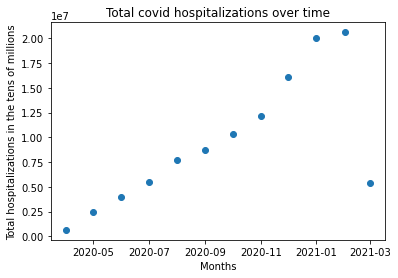

```python
#plot the hospitalizations over time
month_table = all_table.groupby(['date'], as_index=False).sum()
month_table['date'] = month_table['date'].dt.to_timestamp()
plt.scatter(month_table['date'], month_table['hospitalized'])
plt.title("Total covid hospitalizations over time")
plt.xlabel('Months')
plt.ylabel('Total hospitalizations in the tens of millions')
plt.show()
```

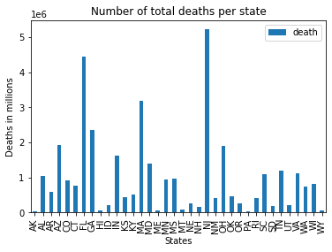

```python
#plot deaths per state
state_table = all_table.groupby(['state'], as_index=False).sum()
plotdata = state_table[['state', 'death']]
plotdata = plotdata.set_index('state')
plotdata.plot(kind="bar")
plt.title("Number of total deaths per state")
plt.xlabel('States')
plt.ylabel('Deaths in millions')
plt.show()
```

```python
#organize the data deaths in certain states over time
tested = all_table[all_table['state'].isin(['FL', 'MA', 'GA', 'AZ', 'OH', 'IN', 'MD', 'TN'])]
tested = tested.pivot(index = 'date', columns = 'state', values = 'death')
tested.head()
```

| state date | AZ | FL | GA | IN | MA | MD | OH | TN |
| --- | --- | --- | --- | --- | --- | --- | --- | --- |
| 2020-04 | 4792.0 | NaN | 17746.0 | NaN | 50046.0 | 15954.0 | 12517.0 | 3672.0 |
| 2020-05 | 19859.0 | 61797.0 | 49289.0 | 52715.0 | 170827.0 | 61681.0 | 49709.0 | 8915.0 |
| 2020-06 | 37298.0 | 92369.0 | 74302.0 | 73069.0 | 228988.0 | 88191.0 | 77119.0 | 14612.0 |
| 2020-07 | 79627.0 | 152519.0 | 98285.0 | 86854.0 | 259483.0 | 103834.0 | 97128.0 | 25120.0 |
| 2020-08 | 137942.0 | 291835.0 | 145359.0 | 97177.0 | 273835.0 | 112721.0 | 118706.0 | 43362.0 |

Now we can look specifically at some important states in their relation to death over time. For the most part the death trend of the states follow the general death trend that we had graphed above in a scatter plot. Most trend positively and then increase more sharply around November 2020 due to Omicron and then dip sharply in March 2021 due to the lack of data.  
Florida stands out with an abnormally sharp increase all throughout 2020 as well as Massachusetts which has a sharp increase in May of 2020 and a smaller increase due to Omicron in November 2020 for some reason. Later we can run other data analyses to see if these different trends in some states can help to better classify the data by deaths.

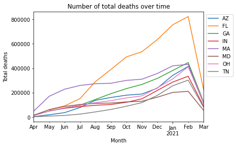

```python
#Plot the deaths in each state dependent on time
tested.plot()
plt.legend(loc='upper left', bbox_to_anchor=(1,1))
plt.xlabel("Month")
plt.ylabel("Total deaths")
plt.title("Number of total deaths over time")
plt.show()
```

We have found that states may help to classify the dataset, lets look at another possible classifier, race. The dataset has data for the death rates of Whites and Blacks, which we can graph using a scatter plot to look for differences in trends.  
Looking at the graph for this data below, we can see a large difference in the total number of deaths between Whites and Blacks, and more importantly different trends. The deaths for Whites follow the general trend better with a sharp increase in November 2020 for Omicron and then a dip in March 2021 due to the lack of data. But the death trend for Blacks tell a whole different story with a steady moderate increase all the way through 2020 into 2021 before the dip in March 2021 again due to lack of data. It would be really useful to run a data analysis on race in relation to deaths later on to see if race can be a classifier to better fit data that just time like what we saw in the first scatter plot.

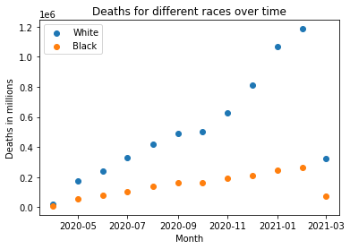

```python
#look at the test for different races over time
race = all_table.groupby(['date'], as_index=False).sum()
plt.scatter(race['date'].dt.to_timestamp(), race['Deaths_White'], label="White")
plt.scatter(race['date'].dt.to_timestamp(), race['Deaths_Black'], label="Black")
leg = plt.legend(loc='upper left')
plt.xlabel("Month")
plt.ylabel("Deaths in millions")
plt.title("Deaths for different races over time")
plt.show()
```

### 4. Hypothesis testing

From the data analysis we have found that the state and the race may have an impact on the total deaths. Additionally, the graphs for the deaths over time as well as the hospitalizations over time both have very similar trends (positively) over time.  
Here I can test the hypothesis that I have developed, primarily that there is a linear positive relationship between deaths, states, race and hospitalizations. The significant level is 5% (0.05) meaning that the deviation from the null hypothesis (that there is no linear relationship) is statistically significant.

I will first visually confirm that what I hypothesize will be true, by plotting the data from the table in relation to deaths and hospitalizations. I can see that there seems to be a positive relation between the two and now I can go forward and statistically prove it true. Linear regression was chosen as it looks to be the best fit for the data without under or overfitting.

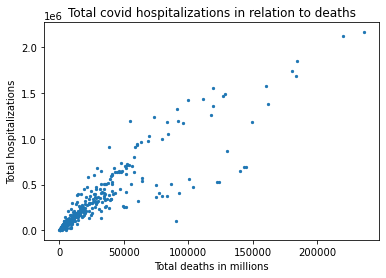

```python
#plot the hospitalizations over number of deaths
plt.scatter(all_table['Deaths_Total'], all_table['hospitalized'], s=5)
plt.title("Total covid hospitalizations in relation to deaths")
plt.xlabel('Total deaths in millions')
plt.ylabel('Total hospitalizations')
plt.show()
```

Here we calculate the linear regression line for Total hospitalizations in relation to Total Deaths. This is a line of best fit which will give me a slope and x-intercept. Below I can see the two values printed, giving us a linear regression model of y = 8.887x + 58333.916 . This means that for each increase in death there is an approximate increase of 9 people hospitalized.

```python
#linear relationship between number of deaths and the number of hospitalizations
x = []
y = all_table['hospitalized']
for i in all_table['Deaths_Total']:
    x.append([i])

#fit the linear regression model
reg = LinearRegression().fit(x, y)
reg.score(x, y)
a = reg.coef_
b = reg.intercept_
print(a[0], b)
```

```
8.886730811524467 58333.91618704607
```

Here to better visualize the linear regression model in relation to the data I have again graphed the total hospitalizations in relation to total death but with the inclusion of the line of best fit which should support my hypothesis. This line can also be used to predict the future number of hospitalizations given the number of deaths.

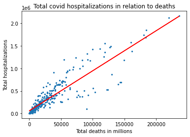

```python
#plot the hospitalizations over number of deaths with line of best fit
plt.scatter(all_table['Deaths_Total'], all_table['hospitalized'], s=5)
plt.plot(x, a*x+b, color='red')
plt.title("Total covid hospitalizations in relation to deaths")
plt.xlabel('Total deaths in millions')
plt.ylabel('Total hospitalizations')
plt.show()
```

Now to run a t-test to confirm of deny my hypothesis. The null hypothesis is that there is no actual relation between two variables. Looking at the results below we can see that the p-values (where P>|t|) for x1 (where x is the total deaths) is below 0.05. 0.0 is below the significance level of 0.05 which means that we will reject the null hypothesis and say that there is a linear relationship between total hospitalizations and total deaths. More specifically there is a positive linear relationship as seen above the slope of the linear regression is positive (8.887).

```python
#display summary of a fit of hospitalizations to deaths
mod = sm.OLS(y,x)
fii = mod.fit()
print(fii.summary())
```

```
                                 OLS Regression Results
=======================================================================================
Dep. Variable:           hospitalized   R-squared (uncentered):                   0.874
Model:                            OLS   Adj. R-squared (uncentered):              0.874
Method:                 Least Squares   F-statistic:                              2583.
Date:                Sun, 11 Dec 2022   Prob (F-statistic):                   1.78e-169
Time:                        05:27:47   Log-Likelihood:                         -5021.2
No. Observations:                 373   AIC:                                  1.004e+04
Df Residuals:                     372   BIC:                                  1.005e+04
Df Model:                           1
Covariance Type:            nonrobust
==============================================================================
                 coef    std err          t      P>|t|      [0.025      0.975]
------------------------------------------------------------------------------
x1             9.6363      0.190     50.821      0.000       9.263      10.009
==============================================================================
Omnibus:                      123.858   Durbin-Watson:                   2.054
Prob(Omnibus):                  0.000   Jarque-Bera (JB):              822.313
Skew:                          -1.225   Prob(JB):                    2.74e-179
Kurtosis:                       9.849   Cond. No.                         1.00
==============================================================================

Notes:
[1] R² is computed without centering (uncentered) since the model does not contain a constant.
[2] Standard Errors assume that the covariance matrix of the errors is correctly specified.
```

```python
#equation for interaction between deaths and state
equation = 'hospitalized ~ Deaths_Total + state:Deaths_Total'
mod = smf.ols(equation, all_table)
fii = mod.fit()
print(fii.summary())
```

```
                            OLS Regression Results
==============================================================================
Dep. Variable:           hospitalized   R-squared:                       0.962
Model:                            OLS   Adj. R-squared:                  0.958
Method:                 Least Squares   F-statistic:                     235.6
Date:                Sun, 11 Dec 2022   Prob (F-statistic):          9.74e-216
Time:                        05:27:47   Log-Likelihood:                -4701.5
No. Observations:                 373   AIC:                             9477.
Df Residuals:                     336   BIC:                             9622.
Df Model:                          36
Covariance Type:            nonrobust
============================================================================================
                               coef    std err          t      P>|t|      [0.025      0.975]
--------------------------------------------------------------------------------------------
Intercept                 1.361e+04   6921.479      1.966      0.050      -8.319    2.72e+04
Deaths_Total                 8.2352     20.863      0.395      0.693     -32.803      49.274
state[T.AL]:Deaths_Total    11.3868     20.841      0.546      0.585     -29.609      52.383
state[T.AR]:Deaths_Total     1.8848     20.843      0.090      0.928     -39.114      42.884
state[T.AZ]:Deaths_Total     5.1067     20.847      0.245      0.807     -35.901      46.114
state[T.CO]:Deaths_Total     4.9206     20.836      0.236      0.813     -36.065      45.906
state[T.CT]:Deaths_Total     0.0219     20.843      0.001      0.999     -40.977      41.021
state[T.FL]:Deaths_Total     1.6646     20.855      0.080      0.936     -39.358      42.688
state[T.GA]:Deaths_Total     4.4337     20.849      0.213      0.832     -36.576      45.444
state[T.HI]:Deaths_Total     4.9480     24.185      0.205      0.838     -42.625      52.521
state[T.ID]:Deaths_Total     3.9684     20.952      0.189      0.850     -37.245      45.182
state[T.IN]:Deaths_Total     4.7285     20.844      0.227      0.821     -36.274      45.730
state[T.KS]:Deaths_Total    -0.7488     20.851     -0.036      0.971     -41.763      40.266
state[T.KY]:Deaths_Total     7.1155     20.842      0.341      0.733     -33.881      48.112
state[T.MA]:Deaths_Total    -3.8261     20.849     -0.184      0.855     -44.838      37.185
state[T.MD]:Deaths_Total     6.1845     20.838      0.297      0.767     -34.805      47.174
state[T.ME]:Deaths_Total    -3.6961     22.658     -0.163      0.871     -48.266      40.874
state[T.MN]:Deaths_Total     5.2210     20.838      0.251      0.802     -35.769      46.211
state[T.MS]:Deaths_Total    -2.7178     20.838     -0.130      0.896     -43.707      38.271
state[T.MT]:Deaths_Total     2.3097     21.354      0.108      0.914     -39.694      44.314
state[T.NE]:Deaths_Total     2.0468     20.918      0.098      0.922     -39.099      43.193
state[T.NH]:Deaths_Total    -6.3123     21.161     -0.298      0.766     -47.937      35.312
state[T.NJ]:Deaths_Total    -1.2351     20.854     -0.059      0.953     -42.256      39.786
state[T.NM]:Deaths_Total     4.2284     20.852      0.203      0.839     -36.789      45.245
state[T.OH]:Deaths_Total     4.1696     20.846      0.200      0.842     -36.836      45.175
state[T.OK]:Deaths_Total    12.5835     20.847      0.604      0.547     -28.423      53.590
state[T.OR]:Deaths_Total     4.9268     20.918      0.236      0.814     -36.220      46.073
state[T.PA]:Deaths_Total    -9.7600     25.026     -0.390      0.697     -58.987      39.467
state[T.RI]:Deaths_Total     1.9917     20.854      0.096      0.924     -39.029      43.012
state[T.SC]:Deaths_Total     0.4940     20.840      0.024      0.981     -40.500      41.488
state[T.SD]:Deaths_Total     3.8753     20.967      0.185      0.853     -37.368      45.119
state[T.TN]:Deaths_Total    -1.4646     20.845     -0.070      0.944     -42.468      39.539
state[T.UT]:Deaths_Total    19.0213     20.961      0.907      0.365     -22.210      60.253
state[T.VA]:Deaths_Total     3.1767     20.838      0.152      0.879     -37.812      44.165
state[T.WA]:Deaths_Total     4.6477     20.834      0.223      0.824     -36.333      45.629
state[T.WI]:Deaths_Total     5.5703     20.841      0.267      0.789     -35.426      46.566
state[T.WY]:Deaths_Total    -3.7371     22.703     -0.165      0.869     -48.396      40.922
==============================================================================
Omnibus:                      124.128   Durbin-Watson:                   1.794
Prob(Omnibus):                  0.000   Jarque-Bera (JB):             5494.823
Skew:                          -0.569   Prob(JB):                         0.00
Kurtosis:                      21.769   Cond. No.                     8.85e+04
==============================================================================

Notes:
[1] Standard Errors assume that the covariance matrix of the errors is correctly specified.
[2] The condition number is large, 8.85e+04. This might indicate that there are
strong multicollinearity or other numerical problems.
```

Lets try again, this time using the race as a category. First create a category using the race. I did this roughly by assigning each data point a race, White if there were more total White deaths and Black if there were more total Black deaths. Now we have two categories that we can run the hypothesis test on again.

```python
#sort each row as either more white deaths or more black deaths
race = []
for x, y in zip(all_table['Deaths_Black'], all_table['Deaths_White']):
    if x < y:
        race.append("White")
    else:
        race.append("Black")

all_table['Race'] = race
```

```python
#equation for interaction between deaths and race
equation = 'hospitalized ~ Deaths_Total + Race:Deaths_Total'
mod = smf.ols(equation, all_table)
fii = mod.fit()
print(fii.summary())
```

```
                            OLS Regression Results
==============================================================================
Dep. Variable:           hospitalized   R-squared:                       0.804
Model:                            OLS   Adj. R-squared:                  0.803
Method:                 Least Squares   F-statistic:                     761.1
Date:                Sun, 11 Dec 2022   Prob (F-statistic):          7.51e-132
Time:                        05:27:48   Log-Likelihood:                -5006.4
No. Observations:                 373   AIC:                         1.002e+04
Df Residuals:                     370   BIC:                         1.003e+04
Df Model:                           2
Covariance Type:            nonrobust
==============================================================================================
                                 coef    std err          t      P>|t|      [0.025      0.975]
----------------------------------------------------------------------------------------------
Intercept                   5.836e+04   1.07e+04      5.468      0.000    3.74e+04    7.93e+04
Deaths_Total                   8.8378      3.260      2.711      0.007       2.428      15.248
Race[T.White]:Deaths_Total     0.0488      3.244      0.015      0.988      -6.331       6.428
==============================================================================
Omnibus:                       64.445   Durbin-Watson:                   2.057
Prob(Omnibus):                  0.000   Jarque-Bera (JB):              434.290
Skew:                          -0.494   Prob(JB):                     4.96e-95
Kurtosis:                       8.193   Cond. No.                     8.25e+04
==============================================================================

Notes:
[1] Standard Errors assume that the covariance matrix of the errors is correctly specified.
[2] The condition number is large, 8.25e+04. This might indicate that there are
strong multicollinearity or other numerical problems.
```

### 5. Insights

I hope that you have learned more about covid from this tutorial. We have gone through data collection, then data management, before performing exploratory data analyses, and finally finishing with hypothesis testing.

First, in data collection we went through some necessary libraries before reading in two csv files on COVID and dropping unneeded columns to declutter the table.

Second, in data management we changed NaN values to 0 and condensed the dates for each table by month. Then we merged the two tables to better clean up the data. We removed repeated and unused columns and helped to fill in some of the missing values in the table.

Fourth, in hypothesis testing we took what we learned from the graphs and decided to create a linear regression prediction model of hospitalizations over deaths as they had similar graphs when we looked at their data analyses. Then we also looked at the interaction of states and race in relation to the two parameters due to their unique trends that we noticed in the exploratory data analysis.